# Interdisciplinary: Joint project report

Report

Reef 6

2023-05-28

### **Investigating the impact of nutrient and sediment loadings from water catchments on macroalgae growth rates, and coral reef health in the Great Barrier Reef?**

# Executive Summary

# Background

The Great Barrier Reef (GBR) is located on the north-east coast of Australia and is home to the world’s largest coral reef ecosystem (Brodie et al., 2012). Despite the GBR being a World Heritage Area and under a protected status, there has been a 52 per cent decrease in coral coverage between 1985 and 2012 (De’Ath et al., 2012). One of the drivers of this decline is the discharge of suspended solids (i.e., sediments) and nutrients from the catchments into the GBR lagoon (Brodie et al., 2012), as a result of wide-scale urban, agricultural and mining development since European settlement (Furnas, 2003). The Queensland and Australian Government has addressed concerns surrounding this issue by implementing the Reef 2050 Plan (Queensland Government, 2023). In regards to agricultural discharge, the Plan establishes various Water Quality Improvement Plans, and strategies to reduce river pollutant run off such as optimising fertiliser use, implementing erosion control measures, and managing land use practices.

Sediment pollution delivered by rivers sources is quantifed by the weight of total suspended solids (TSS). The main annual TSS supply to the GBR lagoon since 1850 has increased 5.5 times to 17,000 ktonnes/yr (Kroon et al., 2012). A primary driver of elevated TSS is deforestation followed by intensive grazing and poor land management (Merten & Minella, 2013). Pastoral grazing has been shown to increase soil erodibility by six per cent and average soil losses by 87 per cent (Donovan & Monaghan, 2021). Despite some coral species being able to tolerate high levels of TSS (Browne, 2012; Sofonia & Anthony, 2008), a majority are negatively affected by reduced light availability to photosynthesise and smothering from sedimentation (Fabricius, 2011). Furthermore, elevated TSS can result in a shift to macroalgal dominance (i.e., coral-algal phase shift), where coral reefs transition to abnormally low coral cover as a result of continued high macroalgae growth and cover (McManus & Polsenberg, 2004; ). Thereby, resulting in a unhealthy coral reef ecosystem (Hughes et al., 2003).

A prevailing stressor on coral reefs is nutrient pollution, specifically phosphorus and nitrogen, via terrestrial runoff. There has been a 13.5-fold increase in the input of anthropogenic nitrogen into the biosphere between 1850 and 2020, with nitrogen fertiliser contributing the most to the increase (Zhao et al., 2021). Such nutrients often enter the GRB lagoon through leaching from the application of excess fertiliser in agricultural processes such as sugarcane farming (Ghiberto, Libardi & Trivelin, 2015), as well as the loss of particulate bound nutrients due to soil erosion (Waterhouse et al., 2012). The resulting elevated nutrient levels induce eutrophication; however it is unlikely that nutrient levels alone will lead to coral-algal phase shifts (McCook, 1999). Despite this, elevated nutrient concentrations have been shown to sustain macroalgal dominance, subsequent to elevated TSS levels instigating the shift (Bender-Champ, Diaz-Puldio & Dove, 2017). Moreover, macroalgal dominance (i.e., high macroalgal cover and growth rates) creates positive feedback loops in regards to reducing coral cover and resilience. This is because the elevated macroalgal levels limit coral recruitment, creating a bottleneck in the reproduction of the coral population (Mumby, 2009). This sustained reduction in coral cover creates further space for macroalgal colonisation, ultimately reinforcing the feedback.

With this as the backdrop, the aim of the present research is to show how increased sediment and nutrient discharge into the GBR lagoon from river sources affect macroalgae growth, ultimately impacting coral health. There are 35 river basins that drain into the GBR lagoon; one of which is the Herbet River located just below Hinchinbrook Island in the Herbet catchment (Brodie et al., 2012). The Reef 2050 Plan defines this location as high risk to pollutant discharge. Whereas, the Endeavour River in the Normanby catchment is defined as low risk. A multidisciplinary approach by creating statistical models for each catchment using machine learning to define a relationship between terrestrial runoff and macroalgae will be employed.

# Methods

## Data Collection

Data was collected from eReefs and the Australian Institute of Marine Science (AIMS). eReefs data was sourced for sediment, nutrient, current, temperature and macroalgal growth rate variables. The AIMS dataset consisted of reef surveys which contain key attributes to examine coral health, including; hard coral cover, soft coral cover and algae cover.

## Sediment and Nutrient Data

eReefs data was first interfaced through netCDF and faced significant issues due to the large file sizes. Through integration with Python and the use of Xarray and pandas modules, the data was compressed to a contained dataset at a spatial scale based on our catchments of focus. The daily values for the location were then averaged over a week, and this weekly value was added as a row in a CSV file for 6-month periods between October 2019 - March 2023. This process allowed for the synthesis of consistent data. This first dataset converted daily files into 6-month, by-week CSV’s which are a fraction of the file size (~70MB for 6 months compared to ~5GB for one day).

## Coral Health Data

Data from AIMS was downloaded as a CSV file from the AIMS website on the 30th April 2023. Since the water quality and coral health datasets originated from different sources and no two common identifiers were present, the Euclidian distance between each point was employed to determine the closest match for each row of data. The two rows which had the lowest overall Euclidian distance, with a maximum distance threshold of within one degree, which also had matching dates, were then joined together to form a new dataset. Unfortunately, due to the tight constraints and sparse sampling of the coral health dataset, the new dataset consisted of only 19 entries.

## Data Modelling

Model code:

```python
import pandas as pd
from sklearn.ensemble import RandomForestRegressor
from sklearn.model_selection import train_test_split
from sklearn.preprocessing import StandardScaler
from sklearn.metrics import r2_score, mean_squared_error
from scipy.stats import pearsonr


data = pd.read_csv("Reef-2020-1H.csv")
data1 = pd.read_csv("Reef-2020-2H.csv")
data2 = pd.read_csv("Reef-2021-1H.csv")
data3 = pd.read_csv("Reef-2021-2H.csv")
data4 = pd.read_csv("Reef-2022-1H.csv")
data5 = pd.read_csv("Reef-2022-2H.csv")

reef_data = [data,data1,data2,data3,data4,data5]
reef_data = pd.concat(reef_data)

x = reef_data[['tss', 'DIP', 'DIN', 'PH', 'Turbidity','temp','Oxygen','current_speed','TN','TP']]

test_var = "MA_N_gr"
y = reef_data[[test_var]]

print("STANDARD DEVIATION OF GROWTH: ",reef_data[[test_var]].std())
```

```
## STANDARD DEVIATION OF GROWTH:  MA_N_gr    0.006282
## dtype: float64
```

```python
x_train, x_test, y_train, y_test = train_test_split(x,y,random_state=1,test_size=0.2)

x_trainsc = StandardScaler().fit_transform(x_train)
x_testsc = StandardScaler().fit_transform(x_test)
```

```python
rf = RandomForestRegressor()
rf_fit = rf.fit(x_trainsc, y_train)
pred2 = rf_fit.predict(x_testsc)

print("R Squared Score for Random Forest: ", r2_score(pred2, y_test))
```

```
## R Squared Score for Random Forest:  0.6489665603464367
```

```python
print("Feature Importance: ", rf.feature_importances_)
```

```
## Feature Importance:  [0.25857177 0.09076117 0.07664838 0.07758396 0.06480596 0.12544628
##  0.10301112 0.07459929 0.08253254 0.04603952]
```

```python
print("RMSE: ", mean_squared_error(y_test, pred2, squared=False))
```

```
## RMSE:  0.0031149290838003766
```

# Results

# Final Product - Shiny

For our final product we deployed a Shiny Application using our target audience, The Queensland Government Department of Agriculture and Fisheries, as the users in mind. We created sections of the application to help the audience understand the effects of nutrients, sediment, and other factors such as pH, temperature, and current movement on macroalgal growth, which inevitably affects coral health. We use interactive visualisations to achieve this. Our key feature in the app is the risk calculator that allows the user to see the immediate effect of changes in the levels of such factors. This application ultimately aims to educate and instigate a change in our audience, to create change in their current methods in agriculture to hopefully create a positive change to our coral reefs and their health.

Link to shiny application - https://reef6.shinyapps.io/reef_app/

Code for the shiny app can be found in folder “Shiny Application” -> “app.R”

# Limitations and future direction

The Shiny application product, inclusive of the risk calculator also has its own limitations. This aspect of the app works off the random forest model that was produced from the eReefs dataset, and by using sliders to change the proportions of variables, a percentage at risk is calculated, where too high of a macroalgal growth rate will cause the increased risk. However, the risk threshold was worked off the mean values for the GBR datasets, so this may not necessarily reflect the real-world. To understand what this threshold may be in these regions of the GBR, extensive literature research was undertaken. Unfortunately, nothing was able to be found, so this would be a great future direction as an improved risk calculator would help various stakeholders understand their impact on the water quality and coral health in the GBR.

# Contributions

# Appendix

## KEY FIGURES -> TO BE MOVED

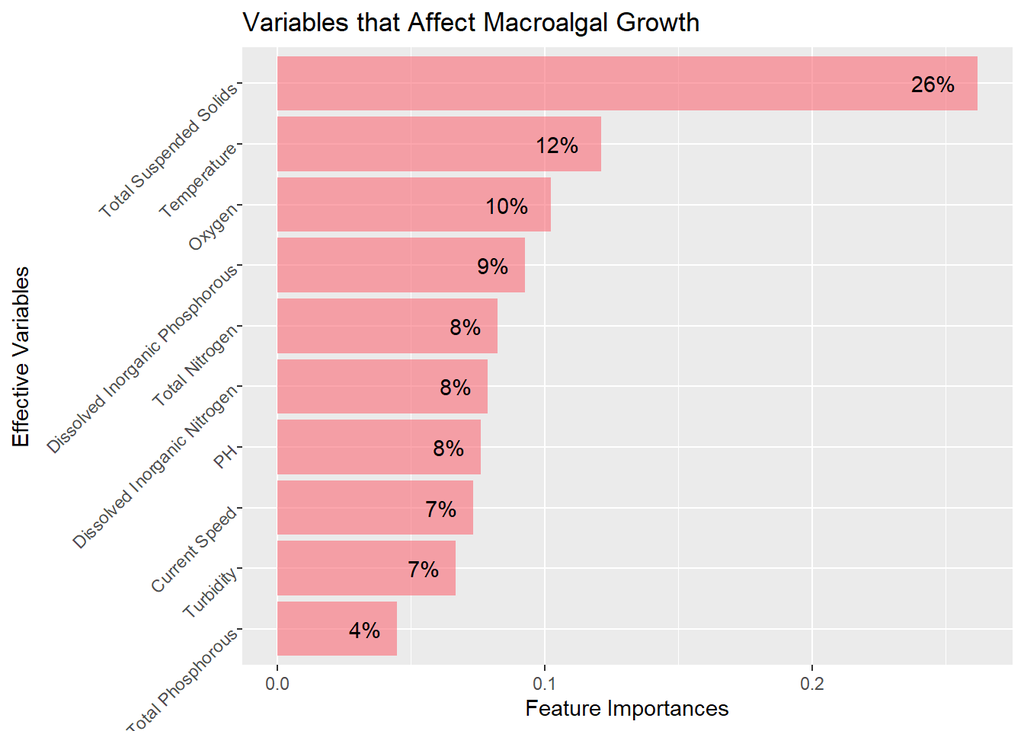

```r
key_cols <- c("Total Suspended Solids", "Dissolved Inorganic Phosphorous", "Dissolved Inorganic Nitrogen", "PH", "Turbidity",
              "Temperature", "Oxygen", "Current Speed", "Total Nitrogen", "Total Phosphorous")

key_importances <- c(0.26181013, 0.09272011, 0.07871058, 0.07615656, 0.06671054,
                     0.12121891, 0.10227495, 0.07321423, 0.08244683, 0.04473716)

# Format the key_importances vector as percentages
key_importances_formatted <- sprintf("%.0f%%", key_importances * 100)

# Create a data frame with the key columns and importances
df_importance <- data.frame(key_cols, key_importances, key_importances_formatted)

ggplot(df_importance, aes(x = reorder(key_cols, +key_importances), y = key_importances)) +
  geom_bar(stat = "identity", fill = "#fa6a77", alpha = 0.6) +
  coord_flip() +
  xlab("Effective Variables") +
  ylab("Feature Importances") +
  ggtitle("Variables that Affect Macroalgal Growth ") +
  geom_text(aes(label = key_importances_formatted), hjust = 1.5) +
  theme(axis.text.y = element_text(angle = 45, hjust = 1))
```

```r
myvars <- c("time", "DIP", "DIN","TN","TP","MA_N_gr","tss","longitude","latitude")

#Herbert Catchment Data Read in CSV and subset the dataframe
reef20201H <- read.csv("Reef-2020-1H.csv")
reef20201H <- reef20201H[myvars]

reef20202H <- read.csv("Reef-2020-2H.csv")
reef20202H <- reef20202H[myvars]

reef20211H <- read.csv("Reef-2021-1H.csv")
reef20211H <- reef20211H[myvars]

reef20212H <- read.csv("Reef-2021-2H.csv")
reef20212H <- reef20212H[myvars]

reef20221H <- read.csv("Reef-2022-1H.csv")
reef20221H <- reef20221H[myvars]

reef20222H <- read.csv("Reef-2022-2H.csv")
reef20222H <- reef20222H[myvars]

df <- rbind(reef20201H,reef20202H,reef20211H,reef20212H,reef20221H,reef20222H)

df$DIP <- log(df$DIP)
df$DIN <- log(df$DIN)

df$TN <- log(df$TN)
df$TP <- log(df$TP)

df$tsslog <- log(df$tss)


df$MA_N_grlog <- (df$MA_N_gr + 0.1)
df$MA_N_grlog <- log(df$MA_N_grlog)

#Normanby DF
#Read in CSV and subset the dataframe
cleanreef20201H <- read.csv("Clean Reef 2020 1H.csv")
cleanreef20201H <- cleanreef20201H[myvars]

cleanreef20202H <- read.csv("Clean Reef 2020 2H.csv")
cleanreef20202H <- cleanreef20202H[myvars]

cleanreef20211H <- read.csv("Clean Reef 2021 1H.csv")
cleanreef20211H <- cleanreef20211H[myvars]

cleanreef20212H <- read.csv("Clean Reef 2021 2H.csv")
cleanreef20212H <- cleanreef20212H[myvars]

cleanreef20221H <- read.csv("Clean Reef 2022 1H.csv")
cleanreef20221H <- cleanreef20221H[myvars]

cleanreef20222H <- read.csv("Clean Reef 2022 2H.csv")
cleanreef20222H <- cleanreef20222H[myvars]

cleandf <- rbind(cleanreef20201H,cleanreef20202H,cleanreef20211H,cleanreef20212H,cleanreef20221H,cleanreef20222H)

cleandf$DIP <- log(cleandf$DIP)
cleandf$DIN <- log(cleandf$DIN)

cleandf$TN <- log(cleandf$TN)
cleandf$TP <- log(cleandf$TP)

cleandf$tsslog <- log(cleandf$tss)


cleandf$MA_N_grlog <- (cleandf$MA_N_gr + 0.1)
cleandf$MA_N_grlog <- log(cleandf$MA_N_grlog)

#get year
df$year <- substr(df$time, start = 1, stop = 4)
avg <- df %>%
  group_by(year) %>%
  summarise(across(starts_with('MA'), mean))

cleandf$year <- substr(cleandf$time, start = 1, stop = 4)
cleanavg <- cleandf %>%
  group_by(year) %>%
  summarise(across(starts_with('MA'), mean))


#Get the season
df <- df %>%
  mutate(result=case_when(
    substr(df$time, start = 6, stop = 7)== "12"  ~ "Summer",
    substr(df$time, start = 6, stop = 7)== "01"  ~ "Summer",
    substr(df$time, start = 6, stop = 7)== "02"  ~ "Summer",
    substr(df$time, start = 6, stop = 7)== "03"  ~ "Autumn",
    substr(df$time, start = 6, stop = 7)== "04"  ~ "Autumn",
    substr(df$time, start = 6, stop = 7)== "05"  ~ "Autumn",
    substr(df$time, start = 6, stop = 7)== "06"  ~ "Winter",
    substr(df$time, start = 6, stop = 7)== "07"  ~ "Winter",
    substr(df$time, start = 6, stop = 7)== "08"  ~ "Winter",
    TRUE ~ "Spring"
  ))

cleandf <- cleandf %>%
  mutate(result=case_when(
    substr(cleandf$time, start = 6, stop = 7)== "12"  ~ "Summer",
    substr(cleandf$time, start = 6, stop = 7)== "01"  ~ "Summer",
    substr(cleandf$time, start = 6, stop = 7)== "02"  ~ "Summer",
    substr(cleandf$time, start = 6, stop = 7)== "03"  ~ "Autumn",
    substr(cleandf$time, start = 6, stop = 7)== "04"  ~ "Autumn",
    substr(cleandf$time, start = 6, stop = 7)== "05"  ~ "Autumn",
    substr(cleandf$time, start = 6, stop = 7)== "06"  ~ "Winter",
    substr(cleandf$time, start = 6, stop = 7)== "07"  ~ "Winter",
    substr(cleandf$time, start = 6, stop = 7)== "08"  ~ "Winter",
    TRUE ~ "Spring"
  ))

#Rename result column
colnames(df)[colnames(df) == "result"] = "season"
colnames(cleandf)[colnames(cleandf) == "result"] = "season"
```

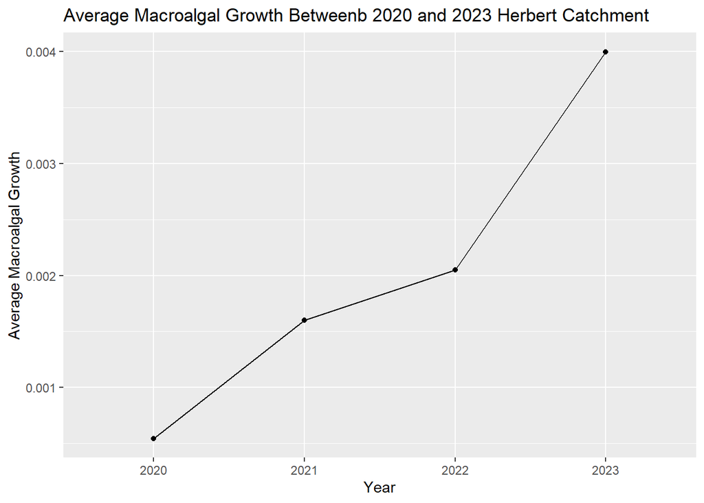

```r
ggplot(data=avg, aes(x=year, y=MA_N_gr, group=1)) +
  geom_line()+
  geom_point() + ggtitle(paste0("Average Macroalgal Growth Betweenb 2020 and 2023 Herbert Catchment")) +
  ylab("Average Macroalgal Growth") + xlab("Year")
```

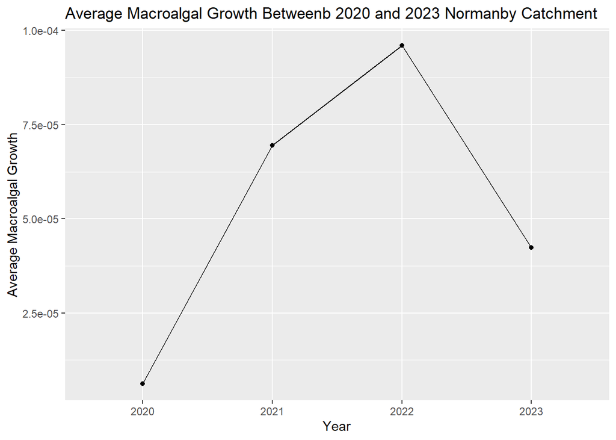

```r
ggplot(data=cleanavg, aes(x=year, y=MA_N_gr, group=1)) +
  geom_line()+
  geom_point() + ggtitle(paste0("Average Macroalgal Growth Betweenb 2020 and 2023 Normanby Catchment")) +
  ylab("Average Macroalgal Growth") + xlab("Year")
```

GRAPH FOR SEDIMENT

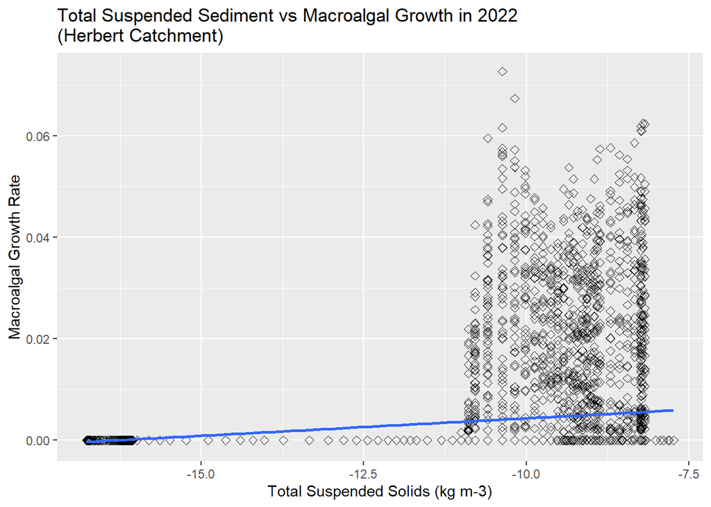

```r
All2022Sediment <- subset(df, year == 2022)
    ggplot(All2022Sediment, aes(x=tsslog, y= MA_N_gr)) +
      geom_point(size=2, shape=23) +
      geom_smooth(method=lm) + ggtitle(paste0("Total Suspended Sediment vs Macroalgal Growth in 2022","\n","(Herbert Catchment)")) +
      xlab("Total Suspended Solids (kg m-3)") +
      ylab("Macroalgal Growth Rate")
```

GRAPH FOR NUTRIENT

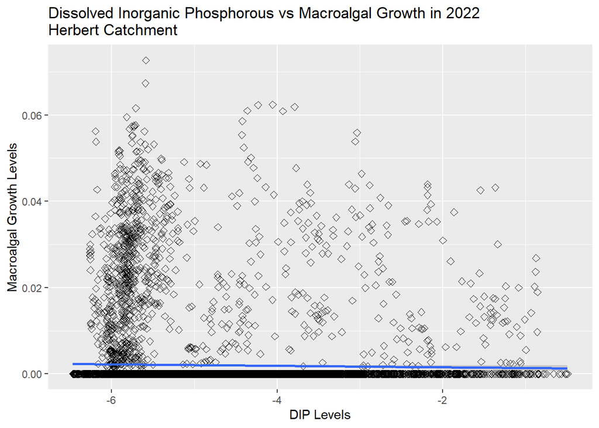

```r
All2022DIP <- subset(df, year == 2022)

ggplot(data = All2022DIP, aes(x= DIP, y= MA_N_gr)) +
  geom_point(size=2, shape=23) + geom_smooth(method=lm) +
  ggtitle(paste0("Dissolved Inorganic Phosphorous vs Macroalgal Growth in 2022","\n","Herbert Catchment")) + xlab(paste0("DIP Levels")) + ylab("Macroalgal Growth Levels")
```

# References

Bender-Champ, D., Diaz-Pulido, G., & Dove, S. (2017). Effects of elevated nutrients and CO2 emission scenarios on three coral reef macroalgae. Harmful Algae, 65, 40-51.

Brodie, J.E., Kroon, F.J., Schaffelke, B., Wolanski, E.C., Lewis, S.E., Devlin, M.J., Bohnet, I.C., Bainbridge, Z.T., Waterhouse, J. and Davis, A.M. (2012). Terrestrial pollutant runoff to the Great Barrier Reef: an update of issues, priorities and management responses. Marine pollution bulletin, 65(4-9), 81-100.

Browne, N. K. (2012). Spatial and temporal variations in coral growth on an inshore turbid reef subjected to multiple disturbances. Marine environmental research, 77, 71-83.

De’Ath, G., Fabricius, K. E., Sweatman, H., & Puotinen, M. (2012). The 27–year decline of coral cover on the Great Barrier Reef and its causes. Proceedings of the National Academy of Sciences, 109(44), 17995-17999.

Donovan, M., & Monaghan, R. (2021). Impacts of grazing on ground cover, soil physical properties and soil loss via surface erosion: A novel geospatial modelling approach. Journal of Environmental Management, 287, 112206.

Fabricius, K. E. (2011). Factors determining the resilience of coral reefs to eutrophication: a review and conceptual model. Coral reefs: an ecosystem in transition, 493-505.

Ghiberto, P. J., Libardi, P. L., & Trivelin, P. C. O. (2015). Nutrient leaching in an Ultisol cultivated with sugarcane. Agricultural Water Management, 148, 141-149.

Hughes, T.P., Baird, A.H., Bellwood, D.R., Card, M., Connolly, S.R., Folke, C., Grosberg, R., Hoegh-Guldberg, O., Jackson, J.B., Kleypas, J. and Lough, J.M. (2003). Climate change, human impacts, and the resilience of coral reefs. science, 301(5635), 929-933.

Kroon, F.J., Kuhnert, P.M., Henderson, B.L., Wilkinson, S.N., Kinsey-Henderson, A., Abbott, B., Brodie, J.E. and Turner, R.D. (2012). River loads of suspended solids, nitrogen, phosphorus and herbicides delivered to the Great Barrier Reef lagoon. Marine pollution bulletin, 65(4-9), 167-181.

McCook, L. J. (1999). Macroalgae, nutrients and phase shifts on coral reefs: scientific issues and management consequences for the Great Barrier Reef. Coral reefs, 18, 357-367.

McManus, J. W., & Polsenberg, J. F. (2004). Coral–algal phase shifts on coral reefs: ecological and environmental aspects. Progress in Oceanography, 60(2-4), 263-279.

Merten, G. H., & Minella, J. P. (2013). The expansion of Brazilian agriculture: soil erosion scenarios. International Soil and Water Conservation Research, 1(3), 37-48.

Mumby, P. J. (2009). Phase shifts and the stability of macroalgal communities on Caribbean coral reefs. Coral Reefs, 28(3), 761-773. Queensland Government. (2023). Reef 2050 Long-term Sustainability Plan. https://www.qld.gov.au/environment/coasts-waterways/reef/sustainability-plan

Sofonia, J. J., & Anthony, K. R. (2008). High-sediment tolerance in the reef coral Turbinaria mesenterina from the inner Great Barrier Reef lagoon (Australia). Estuarine, Coastal and Shelf Science, 78(4), 748-752.

Waterhouse, J., Brodie, J., Lewis, S., & Mitchell, A. (2012). Quantifying the sources of pollutants in the Great Barrier Reef catchments and the relative risk to reef ecosystems. Marine pollution bulletin, 65(4-9), 394-406.

Zhao, H., Yuan, M., Strokal, M., Wu, H.C., Liu, X., Murk, A., Kroeze, C. and Osinga, R. (2021). Impacts of nitrogen pollution on corals in the context of global climate change and potential strategies to conserve coral reefs. Science of the Total Environment, 774, 145017.